# Week3: Tidying data tables

# Week3: Tidying data tables

A 2014 Boston (Logan airport) flight data summary table will be used in this tutorial. The summary displays average (arithmetic mean) delay time (in minutes) by day of the work week and quarter. The following chunk of code recreates the data.

```r
df <- data.frame( Weekday = c( "Mon", "Tues", "Wed", "Thurs", "Fri" ),
                  Q1      = c(  9.9 ,  4.9  ,  8.8 ,   12.2 ,  12.2 ),
                  Q2      = c(  5.4 ,  9.7  , 11.1 ,   10.2 ,   8.1 ),
                  Q3      = c(  8.8 ,  7.9  , 10.2 ,   9.2  ,   7.9 ),
                  Q4      = c(  6.9 ,    5  ,  9.3 ,   9.7  ,   5.6 ) )
```

# Introduction

Reshaping a table involves modifying the layout (or changing the “shape”) of a table. In our example, `df` is in a “wide” format.

| Weekday | Q1 | Q2 | Q3 | Q4 |
| --- | --- | --- | --- | --- |
| Mon | 9.9 | 5.4 | 8.8 | 6.9 |
| Tues | 4.9 | 9.7 | 7.9 | 5.0 |
| Wed | 8.8 | 11.1 | 10.2 | 9.3 |
| Thurs | 12.2 | 10.2 | 9.2 | 9.7 |
| Fri | 12.2 | 8.1 | 7.9 | 5.6 |

A package that facilitates converting from wide to long (and *vice versa*) is `tidyr`. To go from wide to long, we use the `gather` function and from long to wide, we use the `spread` function.

# Creating a long table from a wide table

The `gather` function takes three arguments:

- `key=`: This is the name of the new column which will combine all values associated with the variable type associated with each column (e.g. `Q1`, `Q2`, `Q3` and `Q4`).
- `value=`: This is the name of the new column which will list all values associated with a unique row and column variable (e.g. average delay times)
- The third parameter does not have a name, but is a list of columns that are to be collapsed. The column can be referenced by column number or column name.

In our example, the line of code needed to re-express the table into a long form can be written in one of three ways:

```r
library(tidyr)
df.l <- gather(df, key = "Quarter", value = "Delay" , Q1, Q2, Q3, Q4 )
# or
df.l <- gather(df, key = "Quarter", value = "Delay" ,  2:5           )
# or
df.l <- gather(df, key = "Quarter", value = "Delay" ,  -Weekday      )
```

All three lines produce the same output, they differ only by how we are referencing the columns that are to be collapsed. Note that we assigned the names `Quarter` and `Delay` to the two new columns.

The first 10 lines of the output table are shown here. Note how each `Delay` value has its own row.

```
##    Weekday Quarter Delay
## 1      Mon      Q1   9.9
## 2     Tues      Q1   4.9
## 3      Wed      Q1   8.8
## 4    Thurs      Q1  12.2
## 5      Fri      Q1  12.2
## 6      Mon      Q2   5.4
## 7     Tues      Q2   9.7
## 8      Wed      Q2  11.1
## 9    Thurs      Q2  10.2
## 10     Fri      Q2   8.1
```

The following figure summarises the wide to long conversion.

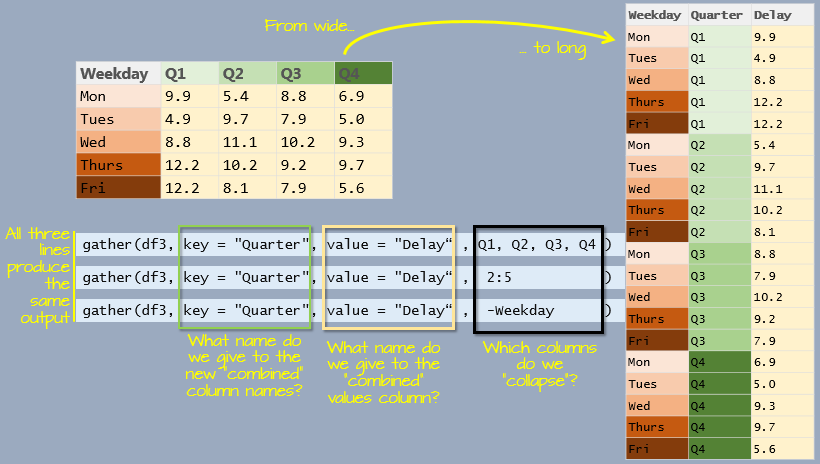

# Creating a wide table from a long table

If a table is to be used for a visual assessment of the values, a long format may be difficult to work with. A long table can be re-expressed into a wide form by picking the two variables that will define the new unique rows and columns.

Continuing with our example, we will convert `df.l` back to a wide format.

```r
df.w <-  spread( df.l ,   key = Quarter  ,   value = Delay  )
```

We’ve now recreated the wide version of our table.

```
##   Weekday   Q1   Q2   Q3  Q4
## 1     Fri 12.2  8.1  7.9 5.6
## 2     Mon  9.9  5.4  8.8 6.9
## 3   Thurs 12.2 10.2  9.2 9.7
## 4    Tues  4.9  9.7  7.9 5.0
## 5     Wed  8.8 11.1 10.2 9.3
```

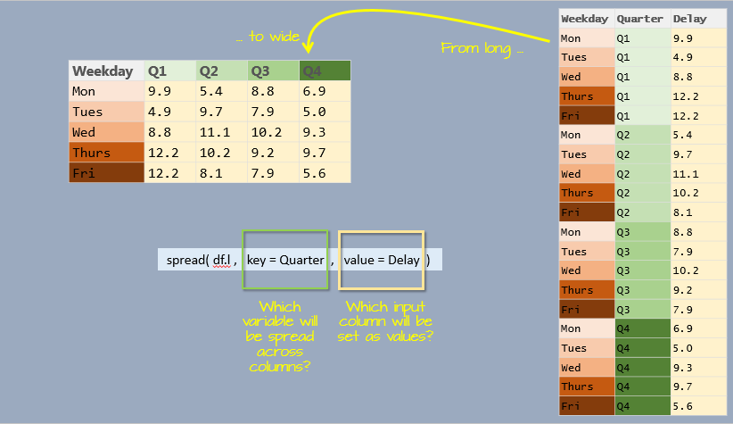

Manny Gimond (2015)